# 5243_Project1

Yufei Wang

2023-09-13

```r
urlfile<-'https://raw.githubusercontent.com/rit-public/HappyDB/master/happydb/data/cleaned_hm.csv'
hm_data <- read_csv(urlfile)
```

```r
urlfile<-'https://raw.githubusercontent.com/rit-public/HappyDB/master/happydb/data/demographic.csv'
demographic_data <- read_csv(urlfile)
```

#Clean the data

Firstly I cleaned the raw data and combined it with demographic data.

```r
hm_data <- hm_data %>%
  inner_join(demographic_data, by = "wid") %>%
  select(wid,
         gender,
         marital,
         parenthood,
         reflection_period,
         age,
         country,
         original_hm,
         ground_truth_category,
         predicted_category,
         text) %>%
  mutate(count = sapply(hm_data$text, wordcount)) %>%
  filter(marital %in% c("single", "married","divorced","separated","widowed")) %>%
  filter(gender %in% c("m", "f")) %>%
  filter(parenthood %in% c("n", "y")) %>%
  filter(reflection_period %in% c("24h", "3m")) %>%
  mutate(reflection_period = fct_recode(reflection_period,
                                        months_of_3 = "3m", hours_of_24 = "24h"))
head(hm_data)
```

```
## # A tibble: 6 × 12
##     wid gender marital  parenthood reflection_period   age country original_hm
##   <dbl> <chr>  <chr>    <chr>      <fct>             <dbl> <chr>   <chr>
## 1  2053 m      single   n          hours_of_24          35 USA     "I went on a…
## 2     2 m      married  y          hours_of_24          29 IND     "I was happy…
## 3  1936 f      married  y          hours_of_24          30 USA     "I went to t…
## 4   206 f      married  n          hours_of_24          28 DNK     "We had a se…
## 5  6227 f      divorced y          hours_of_24          55 USA     "I went with…
## 6    45 m      single   n          hours_of_24          23 IND     "I meditated…
## # ℹ 4 more variables: ground_truth_category <chr>, predicted_category <chr>,
## #   text <chr>, count <int>
```

#Grouping by continent

From the data frame, we can see that there are many topics that we can choose to analyze, such as people’s gender, martial region, etc. I decided to analyze people’s happy moment by region. Firstly I’m going to demonstrate all of the countries in the table, and categorize them into different continent.

```r
table(hm_data$country)
```

```
##
##   AFG   ALB   ARE   ARG   ARM   ASM   AUS   AUT   BEL   BGD   BGR   BHS   BRA
##    11    48    35     6    15    13   117    17    12    69    67     3   123
##   BRB   CAN   CHL   COL   CRI   CYP   CZE   DEU   DNK   DOM   DZA   ECU   EGY
##     6   549     6    32     3     3     6    84    51    50    12     3    57
##   ESP   EST   ETH   FIN   FRA   GBR   GHA   GMB   GRC   GTM   HKG   HRV   IDN
##    23     6     3    21    51   363     3     6    42     6     3     6    90
##   IND   IRL   IRQ   ISL   ISR   ITA   JAM   JPN   KAZ   KEN   KNA   KOR   KWT
## 16689    30     3     9     3    36    60    15     3    33     9     6    18
##   LKA   LTU   LVA   MAR   MDA   MEX   MKD   MLT   MUS   MYS   NGA   NIC   NLD
##    12    42     3     6    36   126    98     9     3    15    81    15    15
##   NOR   NPL   NZL   PAK   PER   PHL   POL   PRI   PRT   ROU   RUS   SAU   SGP
##     3     6    36    39    34   279    15    30    84    46    30     3    24
##   SLV   SRB   SUR   SVN   SWE   TCA   THA   TTO   TUN   TUR   TWN   UGA   UKR
##     3    96     3     6    27     6    87    30     3    51     9    18     3
##   UMI   URY   USA   VEN   VIR   VNM   ZAF   ZMB
##    15    42 78056   588     3   125    21     3
```

```r
data_asia <- hm_data[hm_data$country %in% c("AFG", "ARE", "ARM", "BGD", "BHR", "HKG", "IDN", "IND", "IRQ", "ISR", "JPN", "KAZ", "KOR", "KWT", "LKA", "MYS", "NPL", "PAK", "SAU", "SGP", "THA", "TWN", "UMI", "VNM"),]

data_europe <- hm_data[hm_data$country %in% c("ALB", "AUT", "BGR", "CYP", "CZE", "DEU", "DNK", "EST", "ESP", "FIN", "FRA", "GBR", "GRC", "HRV", "ITA", "LTU", "LVA", "MDA", "MKD", "MLT", "NOR", "PRT", "ROU", "RUS", "SVN", "SWE", "UKR"),]

data_na <- hm_data[hm_data$country %in% c("CAN", "USA"),]

data_sa <- hm_data[hm_data$country %in% c("ARG", "BRA", "CHL", "COL", "PER", "PRI", "VEN", "SUR", "URY"),]

data_oceania <- hm_data[hm_data$country %in% c("ASM", "AUS", "FJI", "KIR", "MHL", "NCL", "NZL", "PNG", "SLB", "TON", "TUV", "VUT"),]

data_africa <- hm_data[hm_data$country %in% c("DZA", "ETH", "GHA", "GMB", "KEN", "MAR", "NGA", "ZAF", "ZMB"),]

data_caribbean <- hm_data[hm_data$country %in% c("BRB", "JAM", "KNA", "PRI", "TCA", "TTO"),]
```

We can create wordclouds for each of the continent respectively.

#Asia

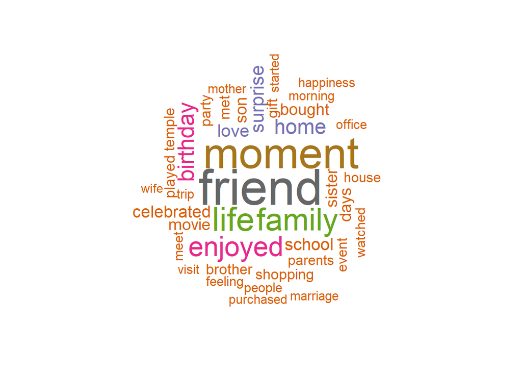

```r
wordcloud(words = data_asia$text, min.freq = 1, max.words=40,
          random.order=FALSE, rot.per=0.4, colors=brewer.pal(8, "Dark2"))
```

#Europe

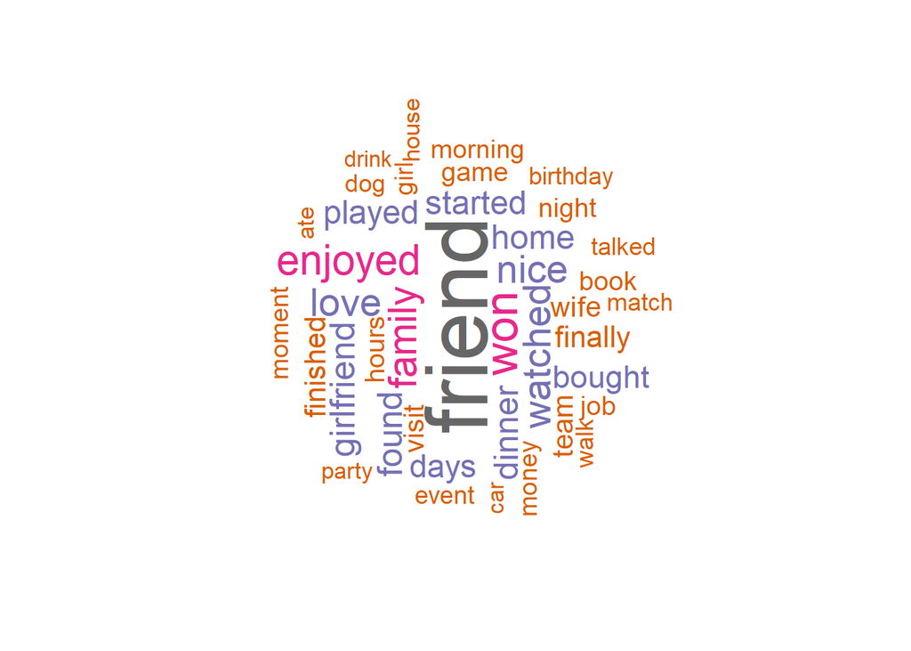

```r
wordcloud(words = data_europe$text, min.freq = 1, max.words=40,
          random.order=FALSE, rot.per=0.4, colors=brewer.pal(8, "Dark2"))
```

#North America